# ANALYSIS of CLINICAL ACTIVITY

Print report

The following objects were **exported into .RData format** from the `clinical_analysis.R` file to be imported in this report:

- the `check_missing` function
- the `clinical_total` dataframe
- the `clinical_stats_per_year_wide` dataframe
- the `clinical_stats_per_type_long` dataframe
- the `clinical_stats_per_time_wide` dataframe

## 1 - DATA CHECK

Before data analysis, a quick **data check was performed to search for NA values** (amount and %).

```r
check_missing(clinical_total) |>
  rename(
    "Variable" = variable,
    "NA values" = missing,
    "%" = pct,
  ) |>
  kbl(align="c")|>
  kable_styling(
    bootstrap_options = "striped",
    full_width = FALSE,
    position = "center"
  ) |>
  column_spec(1:3, width = "120px")
```

| Variable | NA values | % |
| --- | --- | --- |
| place | 0 | 0 |
| date | 0 | 0 |
| time | 0 | 0 |
| service | 0 | 0 |
| type | 0 | 0 |
| type_cat | 0 | 0 |

## 2 - PATIENTS per YEAR

This is the report of the total amount and running total of **patients visited between 2017 and 2025, grouped by year.**

### 2.1 - Table

```r
clinical_stats_per_year_wide |>
  select(year, patients) |>
  mutate(cumulative = cumsum(patients)) |>
  rename(
    "Year" = year,
    "Patients" = patients,
    "Running" = cumulative
  ) |>
  kbl(align="c")|>
  kable_styling(
    bootstrap_options = "striped",
    full_width = FALSE,
    position = "center"
  ) |>
  column_spec(1:3, width = "120px")
```

| Year | Patients | Running |
| --- | --- | --- |
| 2017 | 378 | 378 |
| 2018 | 858 | 1236 |
| 2019 | 1161 | 2397 |
| 2020 | 1082 | 3479 |
| 2021 | 1234 | 4713 |
| 2022 | 1342 | 6055 |
| 2023 | 792 | 6847 |
| 2024 | 755 | 7602 |
| 2025 | 707 | 8309 |

### 2.2 - Plot

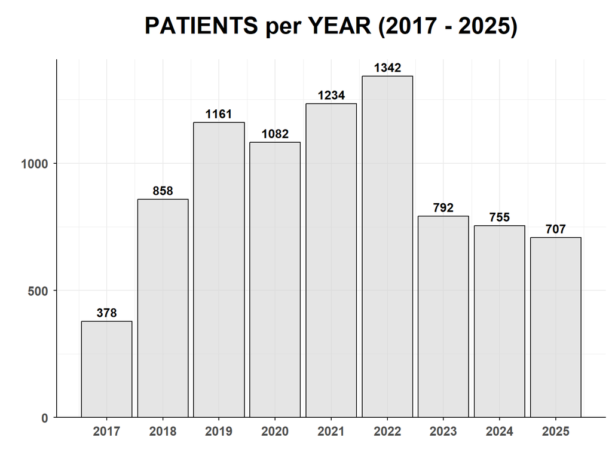

```r
ggplot(
  data = clinical_stats_per_year_wide,
  aes(x = year)
) +
geom_bar(
  aes(y = patients),
  stat = "identity",
  fill = "lightgrey",
  color = "black",
  alpha = 0.6
) +
geom_text(
  aes(y = patients, label = patients),
  vjust = -0.5,
  fontface = "bold",
  size = 4
) +
scale_x_continuous(
  name ="",
  breaks = seq(
    min(clinical_stats_per_year_wide$year),
    max(clinical_stats_per_year_wide$year),
    by = 1
  )
) +
scale_y_continuous(
  name = "",
  expand = expansion(mult = c(0, 0.05))
) +
labs(
  title = paste0(
    "PATIENTS per YEAR (",
    min(clinical_stats_per_year_wide$year),
    " - ",
    max(clinical_stats_per_year_wide$year),
    ")"
  )
) +
my_plot_theme
```

## 3 - VISITS per YEAR and SERVICE

This is the report of the total amount and running total of **visits performed between 2017 and 2025, grouped by year ans service:**

- First visit (new patients)
- Follow-up visits
- Hip US for DDH screening
- Miscellaneous (e.g. cast removal)

### 3.1 - Table

```r
totals_row <- clinical_stats_per_year_wide |>
  summarise(
    year = "",
    visort01 = sum(visort01, na.rm = TRUE),
    visort02 = sum(visort02, na.rm = TRUE),
    ectbac = sum(ectbac, na.rm = TRUE),
    misc = sum(misc, na.rm = TRUE),
    patients = sum(patients, na.rm = TRUE)
  )

clinical_stats_per_year_wide |>
  select(year, visort01, visort02, ectbac, misc, patients) |>
  mutate(year = as.character(year)) |>
  bind_rows(totals_row) |>
  mutate(
    running = ifelse(year == "", "", cumsum(patients))
  ) |>
  rename(
    "Year" = year,
    "First visit" = visort01,
    "Follow-up" = visort02,
    "Hip US" = ectbac,
    "Misc" = misc,
    "Patients" = patients,
    "Running" = running
  ) |>
  kbl(align="c")|>
  kable_styling(
    bootstrap_options = "striped",
    full_width = FALSE,
    position = "center"
  ) |>
  column_spec(1:6, width = "100px")|>
  row_spec(
    nrow(clinical_stats_per_year_wide) + 1,
    bold = TRUE,
    extra_css = "border-top: 2px solid black;"
  )
```

| Year | First visit | Follow-up | Hip US | Misc | Patients | Running |
| --- | --- | --- | --- | --- | --- | --- |
| 2017 | 154 | 172 | 52 | 0 | 378 | 378 |
| 2018 | 338 | 391 | 129 | 0 | 858 | 1236 |
| 2019 | 471 | 492 | 198 | 0 | 1161 | 2397 |
| 2020 | 558 | 391 | 133 | 0 | 1082 | 3479 |
| 2021 | 647 | 412 | 174 | 1 | 1234 | 4713 |
| 2022 | 716 | 402 | 223 | 1 | 1342 | 6055 |
| 2023 | 658 | 85 | 48 | 1 | 792 | 6847 |
| 2024 | 622 | 92 | 39 | 2 | 755 | 7602 |
| 2025 | 570 | 116 | 21 | 0 | 707 | 8309 |
|  | 4734 | 2553 | 1017 | 5 | 8309 |  |

### 3.2 - Plot

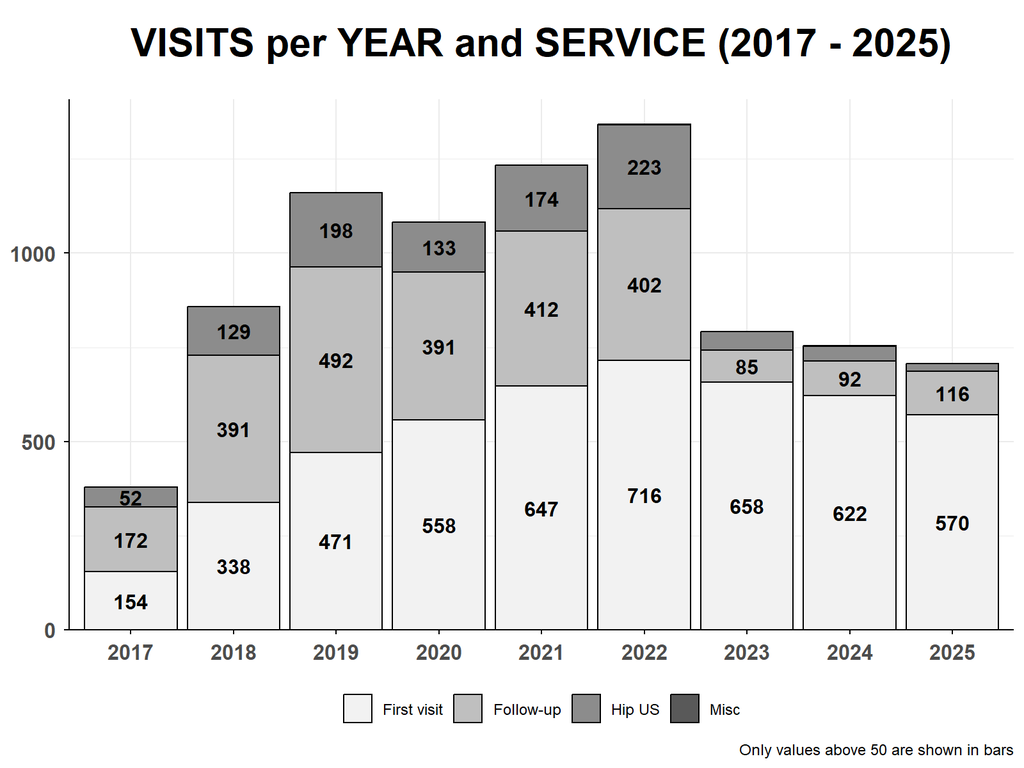

```r
# 1. Convert clinical_stats_per_year from wide to long format
clinical_stats_per_year_long <- clinical_stats_per_year_wide |>
  pivot_longer(
    cols = c("visort01", "visort02", "ectbac", "misc"),
    names_to = "category",
    values_to = "value"
  ) |>
  mutate(category = factor(
    category,
    levels = c("misc", "ectbac", "visort02", "visort01")
    )
  )

# 2. Plot
ggplot(
  data = clinical_stats_per_year_long,
  aes(
    x = factor(year),
    y = value,
    fill = category)
) +
geom_bar(
  stat = "identity",
  position = "stack",
  color = "black"
) +
geom_text(
  aes(label = ifelse(value > 50, as.character(value), "")),
  position = position_stack(vjust = 0.5),
  fontface = "bold",
  size = 4
) +
scale_fill_manual(
  values = c(
    "visort01" = "grey95",
    "visort02" = "grey75",
    "ectbac"   = "grey55",
    "misc"     = "grey35"
  ),
  breaks = c(
    "visort01",
    "visort02",
    "ectbac",
    "misc"
  ),
  labels = c(
    "First visit",
    "Follow-up",
    "Hip US",
    "Misc"
  )
) +
scale_y_continuous(
  name = "",
  expand = expansion(mult = c(0, 0.05))
) +
labs(
  title = paste0(
    "VISITS per YEAR and SERVICE (",
    min(clinical_stats_per_year_long$year),
    " - ",
    max(clinical_stats_per_year_long$year),
    ")"
  ),
  caption = "Only values above 50 are shown in bars",
  x = NULL,
  y = NULL,
  fill = NULL
) +
theme_minimal() +
my_plot_theme +
theme(
  legend.position = "bottom",
  axis.title.x = element_blank(),
  axis.title.y = element_blank()
)
```

## 4 - VISITS per YEAR and TYPE

This is the report of the total amount and running total of **visits performed** **between 2017 and 2025, grouped by year and type:**

- National Health System
- Private practice (no insurance)
- Insurance

### 4.1 - Table

```r
clinical_stats_per_type_wide <- clinical_stats_per_type_long |>
  pivot_wider(
    names_from = type_cat,
    values_from = patients,
    values_fill = 0
  ) |>
  ungroup(year)

totals_row <- clinical_stats_per_type_wide |>
  summarise(
    year = "",
    NHS = sum(as.numeric(NHS), na.rm = TRUE),
    Insurance = sum(as.numeric(Insurance), na.rm = TRUE),
    Private = sum(as.numeric(Private), na.rm = TRUE),
    patients = NHS + Insurance + Private
  )

clinical_stats_per_type_wide |>
  mutate(
    year = as.character(year),
    patients = NHS + Insurance + Private
    ) |>
  bind_rows(totals_row) |>
  mutate(
    running = ifelse(year == "", "", cumsum(patients))
  ) |>
  rename(
    "Year" = year,
    "NHS" = NHS,
    "Insurance" = Insurance,
    "Private" = Private,
    "Patients" = patients,
    "Running" = running
  ) |>
  kbl(align="c")|>
  kable_styling(
    bootstrap_options = "striped",
    full_width = FALSE,
    position = "center"
  ) |>
  column_spec(1:6, width = "100px") |>
  row_spec(
    nrow(clinical_stats_per_type_wide) + 1,
    bold = TRUE,
    extra_css = "border-top: 2px solid black;"
  )
```

| Year | NHS | Private | Insurance | Patients | Running |
| --- | --- | --- | --- | --- | --- |
| 2017 | 378 | 0 | 0 | 378 | 378 |
| 2018 | 858 | 0 | 0 | 858 | 1236 |
| 2019 | 1092 | 33 | 36 | 1161 | 2397 |
| 2020 | 822 | 87 | 173 | 1082 | 3479 |
| 2021 | 844 | 133 | 257 | 1234 | 4713 |
| 2022 | 837 | 229 | 276 | 1342 | 6055 |
| 2023 | 137 | 283 | 372 | 792 | 6847 |
| 2024 | 194 | 232 | 329 | 755 | 7602 |
| 2025 | 212 | 179 | 316 | 707 | 8309 |
|  | 5374 | 1176 | 1759 | 8309 |  |

### 4.2 - Plot

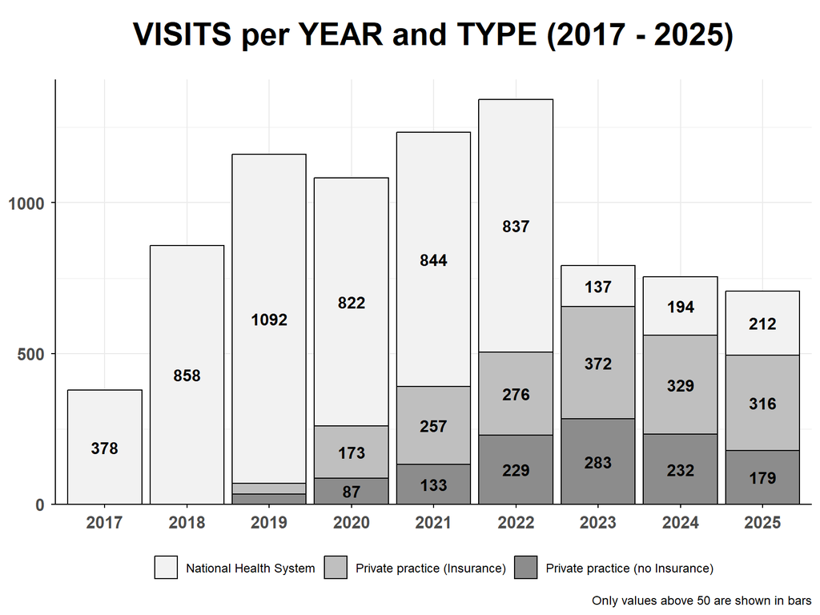

```r
clinical_stats_per_type_long$type_cat <- factor(
  clinical_stats_per_type_long$type_cat,
  levels = c(
      "NHS",
      "Insurance",
      "Private"
    )
)

ggplot(
  data = clinical_stats_per_type_long,
  aes(
    x = factor(year),
    y = patients,
    fill = type_cat)
) +
geom_bar(
  stat = "identity",
  position = "stack",
  color = "black"
) +
geom_text(
  aes(label = ifelse(patients > 50, as.character(patients), "")),
  position = position_stack(vjust = 0.5),
  fontface = "bold",
  size = 4
) +
scale_fill_manual(
  values = c(
    "NHS" = "grey95",
    "Insurance" = "grey75",
    "Private" = "grey55"
  ),
  breaks = c(
    "NHS",
    "Insurance",
    "Private"
  ),
  labels = c(
    "National Health System",
    "Private practice (Insurance)",
    "Private practice (no Insurance)"
  )
) +
scale_y_continuous(
  name = "",
  expand = expansion(mult = c(0, 0.05))
) +
labs(
  title = paste0(
    "VISITS per YEAR and TYPE (",
    min(clinical_stats_per_type_long$year),
    " - ",
    max(clinical_stats_per_type_long$year),
    ")"
  ),
  caption = "Only values above 50 are shown in bars",
  x = NULL,
  y = NULL,
  fill = NULL
) +
theme_minimal() +
my_plot_theme +
theme(
  legend.position = "bottom",
  axis.title.x = element_blank(),
  axis.title.y = element_blank()
)
```

## 5 - PATIENTS per TIME SLOT

This is the report of the total amount and running total of **visits performed, grouped by time slot** (split into 2-hours slots from 08:00 to 20:00).

### 5.1 - Table

```r
clinical_stats_per_time_wide |>
  mutate(
    pct = sprintf("%.2f%%", patients/sum(patients)*100),
    cumulate = cumsum(patients),
    cumulate_pct = sprintf("%.2f%%",cumsum(patients/sum(patients)*100))
  )|>
  rename(
    "Time range" = time_cat,
    "Patients" = patients,
    "%" =  pct,
    "Running" = cumulate,
    "Runinng %" = cumulate_pct
  ) |>
  kbl(align="c")|>
  kable_styling(
    bootstrap_options = "striped",
    full_width = FALSE,
    position = "center"
  ) |>
  column_spec(1, width = "120px") |>
  column_spec(2:5, width = "100px")
```

| Time range | Patients | % | Running | Runinng % |
| --- | --- | --- | --- | --- |
| 08:00 - 10:00 | 44 | 1.27% | 44 | 1.27% |
| 10:00 - 12:00 | 621 | 17.87% | 665 | 19.13% |
| 12:00 - 14:00 | 46 | 1.32% | 711 | 20.45% |
| 14:00 - 16:00 | 1061 | 30.52% | 1772 | 50.98% |
| 16:00 - 18:00 | 1288 | 37.05% | 3060 | 88.03% |
| 18:00 - 20:00 | 416 | 11.97% | 3476 | 100.00% |

### 5.2 - Plot

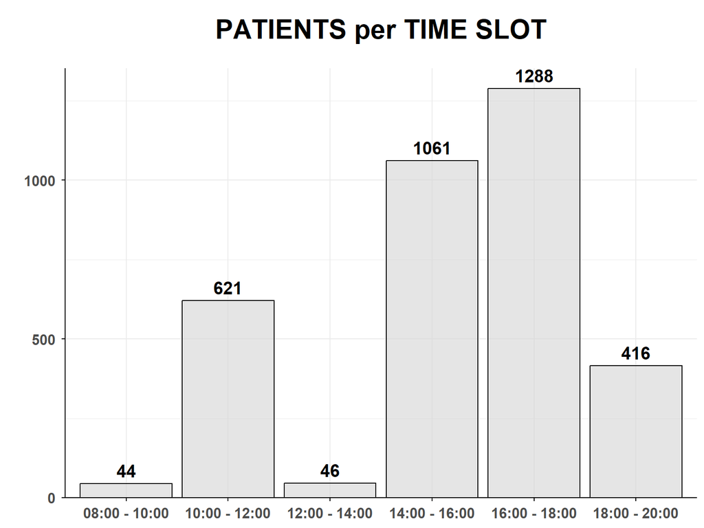

```r
ggplot(
  data = clinical_stats_per_time_wide,
  aes(x = time_cat)
) +
geom_bar(
  aes(y = patients),
  stat = "identity",
  fill = "lightgrey",
  color = "black",
  alpha = 0.6
) +
geom_text(
  aes(y = patients, label = patients),
  vjust = -0.5,
  fontface = "bold",
  size = 5
) +
scale_y_continuous(
  name = "",
  expand = expansion(mult = c(0, 0.05))
) +
labs(
  title = "PATIENTS per TIME SLOT",
  x = NULL
) +
my_plot_theme
```